# AI Impact on Jobs 2030 - Statistical Analysis

## Notebook 2 : Statistical Analysis

Following the descriptive exploration of the AI Impact on Jobs 2030 dataset, this notebook delves deeper into **statistical analyses** to better understand patterns related to automation risk.

We focus on key job characteristics such as salary, experience, education, and AI exposure, and explore their relationships with automation probability. This includes examining distributions, testing statistical assumptions, and applying appropriate analyses to summarize and compare groups.

The main guiding question remains:

**“Which types of jobs are most at risk of automation, and how do job characteristics are distributed across different levels of automation risk?”**

By rigorously examining these variables, we aim to provide clearer insights into the factors associated with automation vulnerability across occupations.

Author: J-F Jutras  
Date: December 2025  
Dataset: AI Impact on Jobs 2030 — Kaggle

## Automation Probability Across Education Levels

**ANOVA: Automation Probability by Education Level**

| term | Sum_Sq | Mean_Sq | F_value | P_value |
| --- | --- | --- | --- | --- |
| Education_Level | 0.072 | 0.024 | 0.389 | 0.761 |
| Residuals | 184.202 | 0.061 | NA | NA |

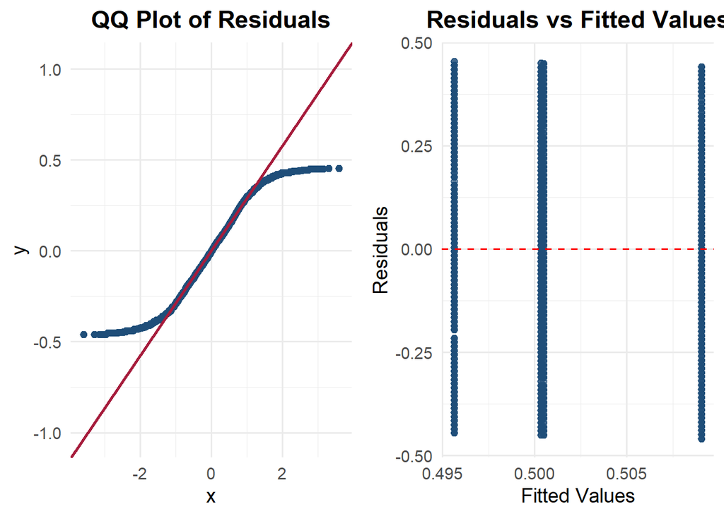

**Normality and Homogeneity Tests for ANOVA**

|  | Test | Statistic | P_value |
| --- | --- | --- | --- |
| W | Shapiro-Wilk (Residuals) | 0.967 | 0.000 |
| …2 | Levene (by Education Level) | 1.595 | 0.189 |

A Kruskal-Wallis test was conducted in lieu of ANOVA due to a violation of the normality assumption in the residuals, whereas the assumption of homogeneity of variances was satisfied.

**Kruskal-Wallis Test for Automation Probability by Education Level**

|  | Statistic | df | p_value |
| --- | --- | --- | --- |
| Kruskal-Wallis chi-squared | 1.2926 | 3 | 0.7309 |

**Post-hoc Dunn Test (Bonferroni-adjusted) for Education Levels**

| Comparison | Z | P_unadj | P_adj | Significant |
| --- | --- | --- | --- | --- |
| Bachelor’s - High School | -0.7752 | 0.4382 | 1 | No |
| Bachelor’s - Master’s | 0.3168 | 0.7514 | 1 | No |
| High School - Master’s | 1.0860 | 0.2775 | 1 | No |
| Bachelor’s - PhD | -0.0054 | 0.9957 | 1 | No |
| High School - PhD | 0.7567 | 0.4492 | 1 | No |
| Master’s - PhD | -0.3169 | 0.7513 | 1 | No |

Both Kruskal-Wallis and Dunn tests confirm that automation probability does not significantly differ between education levels.

## Automation Probability Across Job Title

**ANOVA: Automation Probability by Job Title**

| term | Sum_Sq | Mean_Sq | F_value | P_value |
| --- | --- | --- | --- | --- |
| Job_Title | 157.931 | 8.312 | 940.281 | 0 |
| Residuals | 26.343 | 0.009 | NA | NA |

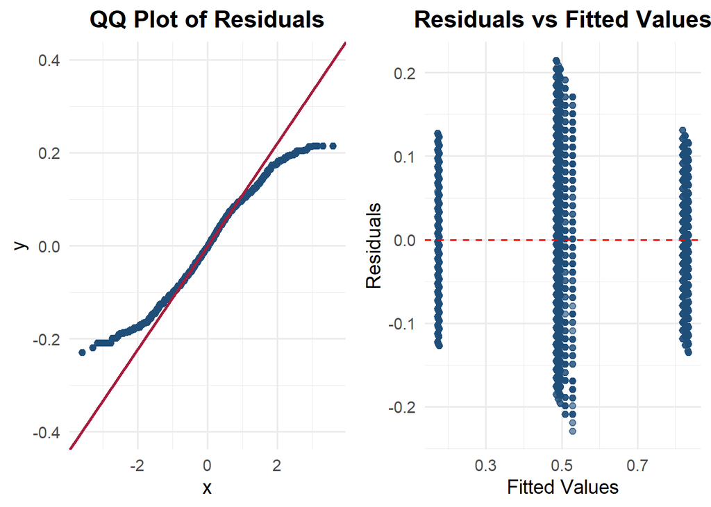

**Normality and Homogeneity Tests for ANOVA**

|  | Test | Statistic | P_value |
| --- | --- | --- | --- |
| W | Shapiro-Wilk (Residuals) | 0.986 | 0 |
| …2 | Levene (by Job Title) | 20.305 | 0 |

A one-way ANOVA revealed a highly significant effect of job title on automation probability but diagnostic tests indicated violations of the normality of residuals and homogeneity of variances. Consequently, a Welch ANOVA will be conducted to account for heteroscedasticity, and results will be complemented with appropriate post-hoc comparisons.

**Welch ANOVA for Automation Probability by Job Title**

|  | Statistic | df_num | df_den | p_value |
| --- | --- | --- | --- | --- |
| F | 1609.366 | 19 | 1088.927 | 0 |

**Games–Howell Post-hoc Comparisons (Top 10)**

| .y. | group1 | group2 | estimate | conf.low | conf.high | p.adj | p.adj.signif |
| --- | --- | --- | --- | --- | --- | --- | --- |
| Automation_Probability_2030 | AI Engineer | Chef | 0.3235 | 0.2818 | 0.3652 | 0 | **** |
| Automation_Probability_2030 | AI Engineer | Lawyer | 0.3142 | 0.2724 | 0.3560 | 0 | **** |
| Automation_Probability_2030 | AI Engineer | Marketing Manager | 0.3226 | 0.2823 | 0.3628 | 0 | **** |
| Automation_Probability_2030 | Chef | Construction Worker | 0.3303 | 0.2894 | 0.3712 | 0 | **** |
| Automation_Probability_2030 | Chef | Nurse | -0.3200 | -0.3620 | -0.2780 | 0 | **** |
| Automation_Probability_2030 | Chef | Research Scientist | -0.3215 | -0.3620 | -0.2810 | 0 | **** |
| Automation_Probability_2030 | Construction Worker | Mechanic | -0.3407 | -0.3800 | -0.3013 | 0 | **** |
| Automation_Probability_2030 | Customer Support | Lawyer | -0.3388 | -0.3801 | -0.2976 | 0 | **** |
| Automation_Probability_2030 | Doctor | Lawyer | 0.3097 | 0.2679 | 0.3515 | 0 | **** |
| Automation_Probability_2030 | Doctor | Mechanic | 0.3086 | 0.2684 | 0.3487 | 0 | **** |

A Welch ANOVA revealed a highly significant effect of job title on automation probability, F(19,1088.93) = 1609.37, p < .001, confirming substantial differences across occupations after accounting for heteroscedasticity.

Together, these findings suggest that exposure to automation is primarily structured by broad occupational task characteristics rather than by individual job titles.

## Risk Category vs. Education Level

**Chi-Square Test for Education Level by Risk Category + Cramer’s V**

|  | Statistic | df | p_value | Cramers_V |
| --- | --- | --- | --- | --- |
| X-squared | 2.7192 | 6 | 0.8432 | 0.0213 |

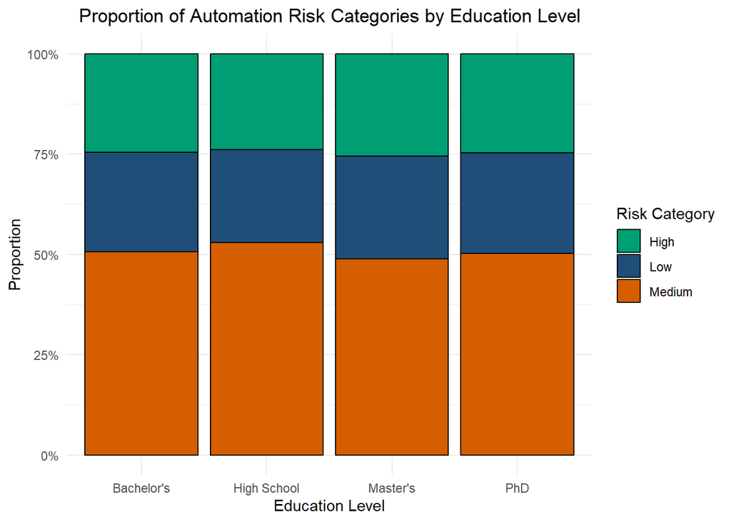

The Kruskal-Wallis test showed no significant differences in automation probability across education levels. Consistently, the Chi-Square test on risk categories indicated no association with Education Level (χ² = 2.72, df = 6, p = 0.843; Cramer’s V = 0.021), suggesting that automation risk is largely independent of formal education.

## Predictors of Automation Probability

Given the bounded nature of the dependent variable and the strong occupational clustering observed in preliminary analyses, a mixed-effects beta regression was estimated with job title specified as a random intercept. This specification allows individual-level predictors to be assessed net of occupational-level heterogeneity.

**Mixed-Effects Beta Regression: Predictors of Automation Probability**

|  | Estimate | Std_Error | z_value | p_value |
| --- | --- | --- | --- | --- |
| (Intercept) | -0.0071 | 0.2489 | -0.0285 | 0.9773 |
| Average_Salary | 0.0000 | 0.0000 | 0.3416 | 0.7327 |
| Years_Experience | -0.0011 | 0.0010 | -1.1707 | 0.2417 |
| AI_Exposure_Index | -0.0150 | 0.0300 | -0.5015 | 0.6160 |
| Tech_Growth_Factor | 0.0206 | 0.0296 | 0.6947 | 0.4872 |

A mixed-effects beta regression was estimated with job title specified as a random intercept to account for occupational-level heterogeneity. After controlling for this clustering, none of the individual-level predictors—average salary, years of experience, AI exposure, or technological growth—were statistically significant. Coefficient estimates were small and close to zero, indicating negligible marginal effects.

These findings suggest that variation in automation probability is largely driven by differences between occupations rather than by individual job characteristics within occupations.

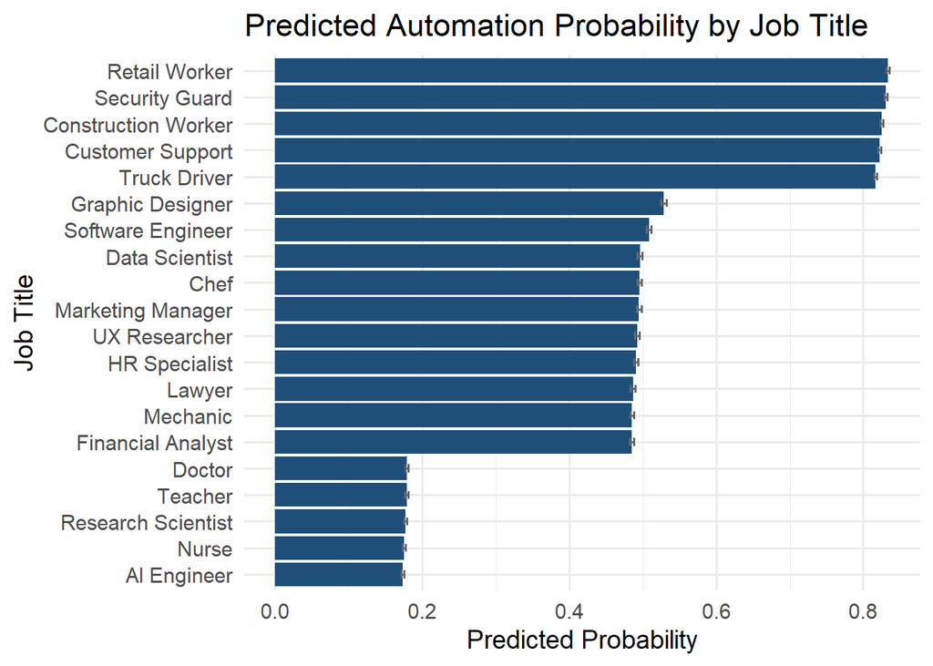

This plot shows the predicted automation probability for each job title from the mixed-effects Beta regression model, with bars representing the mean predicted probability and error bars indicating variability across individuals within each job. Jobs are ordered from lowest to highest risk, highlighting which occupations are most and least exposed to automation.